# Practical 4 Repeated Measurements

## Practical 4: Mixed Effects Models for Discrete Data

We start by loading the packages we will need for this practical and the data from [GitHub](https://github.com/drizopoulos/Repeated_Measurements). This is achieved with the following commands:

```r
# packages
library("lattice")
library("GLMMadaptive")
library("splines")

# data
con <- url("https://raw.github.com/drizopoulos/Repeated_Measurements/master/Data.RData")
load(con)
close(con)
```

### Question 1

The following piece of code creates the dummy variable for abnormal prothrombin time:

```r
pbc2$Dicht_prothro <- as.numeric(with(pbc2, prothrombin < 11 | prothrombin > 13))
```

### Question 2

To examine graphically the shape of the probability of abnormal prothrombin time we can smooth the scatterplot of the `Dicht_prothro` for each patient separately. To obtain more useful information we do that only in patients with five or more measurements. The following line of code creates an indicator variable denoting the rows of the `pbc2` dataset that correspond to patient with five measurements or more:

```r
ind <- with(pbc2, ave(Dicht_prothro, id, FUN = length)) >= 5
```

Next, using function [xyplot()](https://goo.gl/cGSjZk), we plot the smoothed subject-specific profiles of abnormal prothrombin time – here we have opted for option `"spline"` in the `type` argument of [xyplot()](https://goo.gl/cGSjZk):

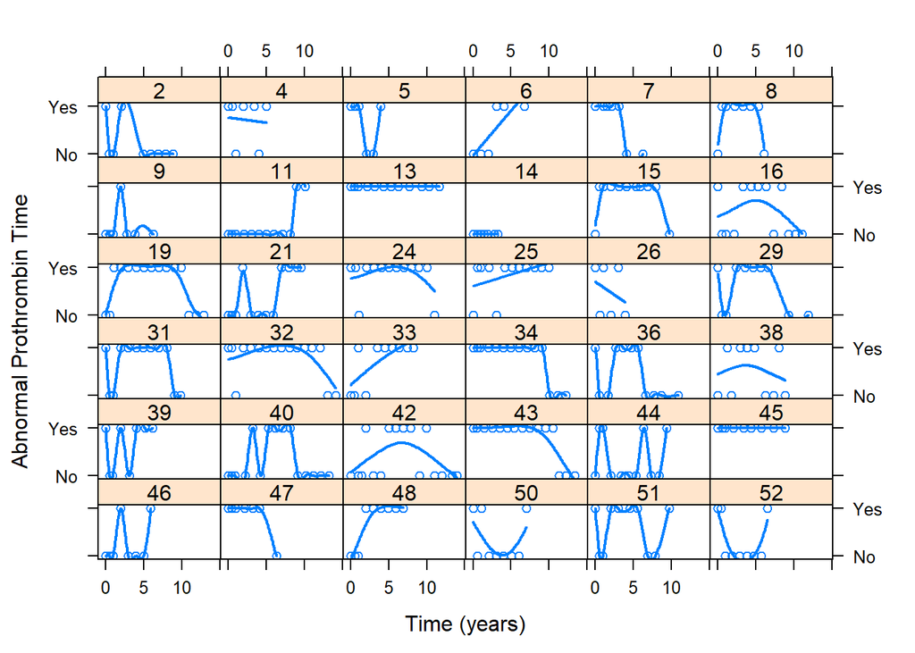

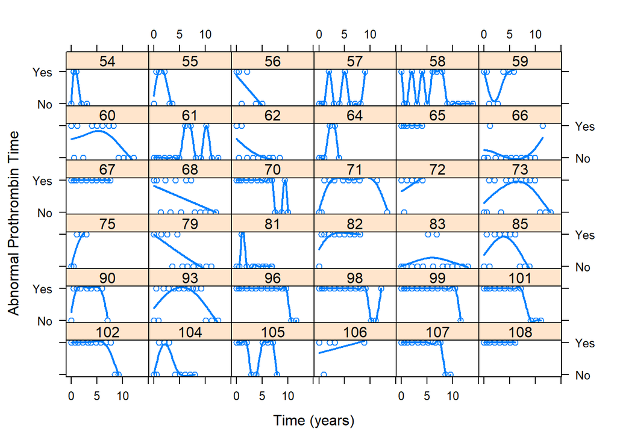

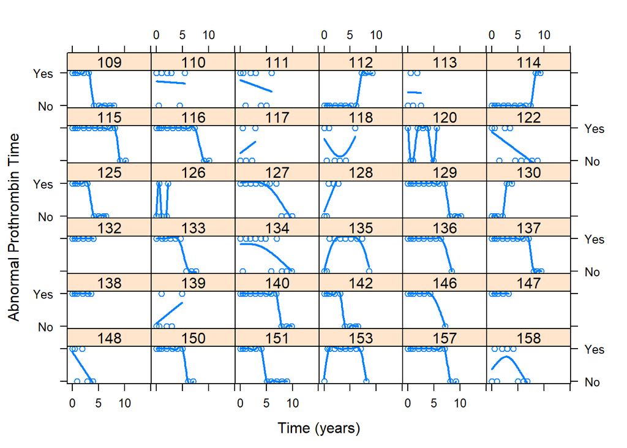

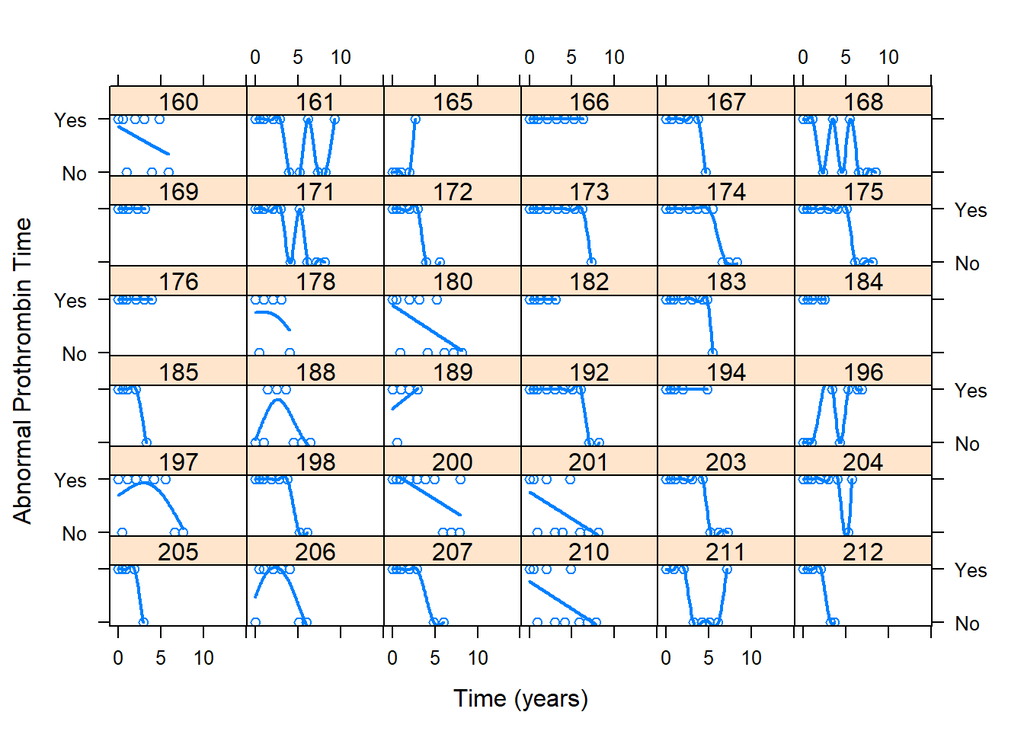

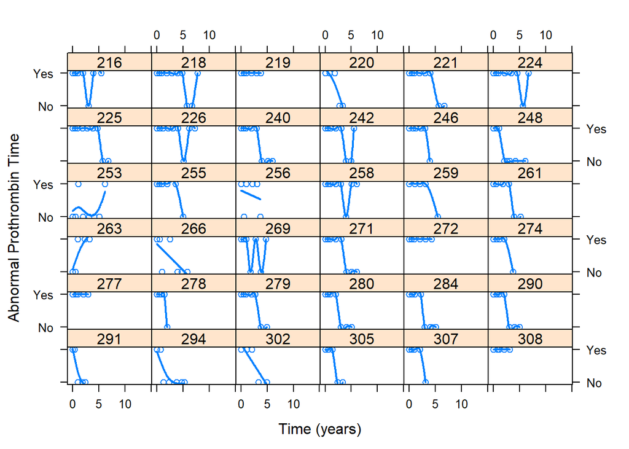

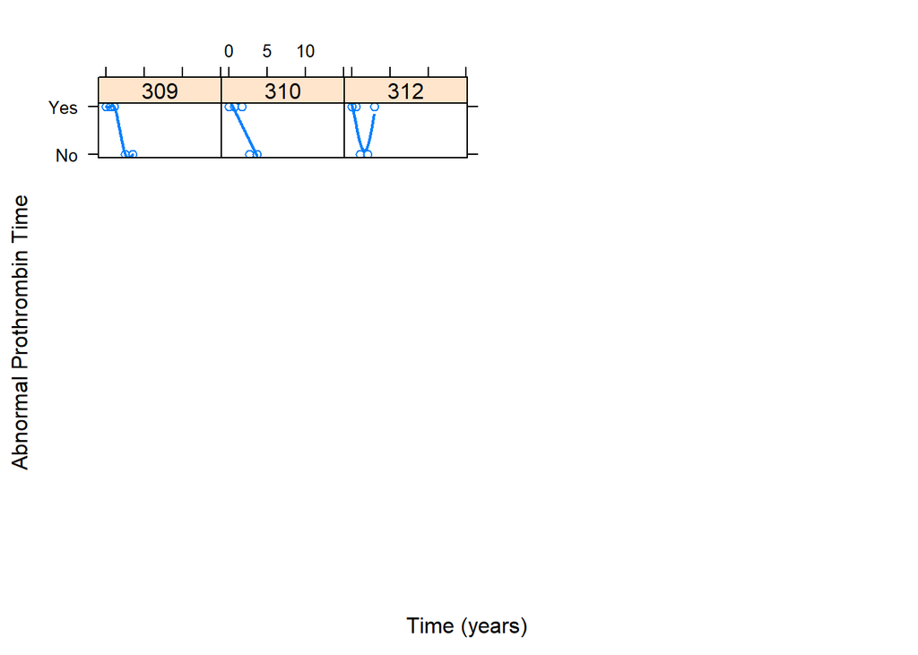

```r
xyplot(Dicht_prothro ~ year | id, data = pbc2, subset = ind,
       type = c("p", "spline"), lwd = 2,
       xlab = "Time (years)", ylab = "Abnormal Prothrombin Time",
       layout = c(6, 6), as.table = TRUE,
       scales = list(y = list(at = 0:1, labels = c("No", "Yes"))))
```

We observe substianl varibility in the shapes of the smoothed longitudinal trajectories. However, due to the fact that we are dealing with dichotomous data, it is always a bit difficult to get a clear picture from these graphs.

### Question 3

Based on the description of Question 3, we need to fit a mixed-effects logistic regression model with random intercepts, and include in the mean structure the linear effect of time, the main effect of sex and drug, the interaction of time with sex and the interaction effect of drug with sex. This model is fitted with following call to function [mixed_model()](https://goo.gl/KyiDVB) (**note:** we also need to set the `family` argument to `binomial()`, and the `nAGQ` argument to 15 to approximate the integrals with 15 quadrature points):

```r
fm_1 <- mixed_model(fixed = Dicht_prothro ~ year * sex + drug + drug:sex,
                    random = ~ 1 | id, data = pbc2, family = binomial(), nAGQ = 15)

summary(fm_1)
```

```
##
## Call:
## mixed_model(fixed = Dicht_prothro ~ year * sex + drug + drug:sex,
##     random = ~1 | id, data = pbc2, family = binomial(), nAGQ = 15)
##
## Data Descriptives:
## Number of Observations: 1945
## Number of Groups: 312
##
## Model:
##  family: binomial
##  link: logit
##
## Fit statistics:
##    log.Lik      AIC      BIC
##  -1174.035 2362.071 2388.272
##
## Random effects covariance matrix:
##               StdDev
## (Intercept) 1.118737
##
## Fixed effects:
##                         Estimate Std.Err z-value    p-value
## (Intercept)              -0.2737  0.4155 -0.6587 0.51011034
## year                     -0.0233  0.0510 -0.4567 0.64786256
## sexfemale                 1.5304  0.4405  3.4744 0.00051206
## drugD-penicil             0.6862  0.5123  1.3395 0.18041994
## year:sexfemale           -0.2126  0.0559 -3.8044 0.00014215
## sexfemale:drugD-penicil  -0.5531  0.5452 -1.0144 0.31040284
##
## Integration:
## method: adaptive Gauss-Hermite quadrature rule
## quadrature points: 15
##
## Optimization:
## method: EM
## converged: TRUE
```

### Question 4

We continue the analysis by re-fitting the model of Question 3 by also including a random slopes term. This is done with the following call to [mixed_model()](https://goo.gl/KyiDVB):

```r
fm_2 <- mixed_model(fixed = Dicht_prothro ~ year * sex + drug + drug:sex,
                    random = ~ year | id, data = pbc2, family = binomial(), nAGQ = 15)
```

The likelihood ratio test is performed using the `anova()`:

```r
anova(fm_1, fm_2)
```

```
##
##          AIC     BIC  log.Lik   LRT df p.value
## fm_1 2362.07 2388.27 -1174.04
## fm_2 2284.53 2318.22 -1133.27 81.54  2 <0.0001
```

The results indicate that the random slopes is required. Nonetheless, due to the fact mixed models for categorical grouped data are more susceptible to numerical problems, it is in general a good idea not only to look at the p-value from the likelihood ratio test, but also at the estimated variance components. By doing this you could pick-up pathological situations in which some variance parameters have converged on the boundary (i.e., very close to zero). Hence, we also inspect the `summary()` of the fitted model with random intercepts and random slopes:

```r
summary(fm_2)
```

```
##
## Call:
## mixed_model(fixed = Dicht_prothro ~ year * sex + drug + drug:sex,
##     random = ~year | id, data = pbc2, family = binomial(), nAGQ = 15)
##
## Data Descriptives:
## Number of Observations: 1945
## Number of Groups: 312
##
## Model:
##  family: binomial
##  link: logit
##
## Fit statistics:
##    log.Lik      AIC     BIC
##  -1133.266 2284.533 2318.22
##
## Random effects covariance matrix:
##              StdDev    Corr
## (Intercept)  2.3307
## year         0.4223 -0.8673
##
## Fixed effects:
##                         Estimate Std.Err z-value  p-value
## (Intercept)              -0.0355  0.6157 -0.0577 0.954002
## year                     -0.0670  0.1061 -0.6319 0.527464
## sexfemale                 1.6624  0.6507  2.5547 0.010628
## drugD-penicil             0.5456  0.6207  0.8790 0.379405
## year:sexfemale           -0.2422  0.1134 -2.1360 0.032676
## sexfemale:drugD-penicil  -0.3187  0.6591 -0.4835 0.628727
##
## Integration:
## method: adaptive Gauss-Hermite quadrature rule
## quadrature points: 15
##
## Optimization:
## method: hybrid EM and quasi-Newton
## converged: TRUE
```

The estimated variances for the random intercepts and random slopes terms do not indicate convergence on the boundary.

### Question 5

Next, we attempt to simplify the model by dropping all interaction terms. The additive mixed effects logistic regression model with only main effects is fitted using the following call to [mixed_model()](https://goo.gl/KyiDVB):

```r
fm_3 <- mixed_model(fixed = Dicht_prothro ~ year + sex + drug,
                    random = ~ year | id, data = pbc2, family = binomial(), nAGQ = 15)
```

Again the likelihood ratio test is calculated using the `anova()` function:

```r
anova(fm_3, fm_2)
```

```
##
##          AIC     BIC  log.Lik  LRT df p.value
## fm_3 2285.09 2311.29 -1135.54
## fm_2 2284.53 2318.22 -1133.27 4.55  2  0.1026
```

The resulting p-value suggests that we can use the simpler additive model.

### Question 6

The estimated fixed-effects coefficients from our final model are:

```r
summary(fm_3)
```

```
##
## Call:
## mixed_model(fixed = Dicht_prothro ~ year + sex + drug, random = ~year |
##     id, data = pbc2, family = binomial(), nAGQ = 15)
##
## Data Descriptives:
## Number of Observations: 1945
## Number of Groups: 312
##
## Model:
##  family: binomial
##  link: logit
##
## Fit statistics:
##    log.Lik      AIC      BIC
##  -1135.543 2285.086 2311.287
##
## Random effects covariance matrix:
##              StdDev    Corr
## (Intercept)  2.3827
## year         0.4448 -0.8734
##
## Fixed effects:
##               Estimate Std.Err z-value  p-value
## (Intercept)     0.8901  0.3663  2.4298 0.015106
## year           -0.2830  0.0415 -6.8155  < 1e-04
## sexfemale       0.6355  0.3344  1.9001 0.057416
## drugD-penicil   0.2557  0.2126  1.2024 0.229194
##
## Integration:
## method: adaptive Gauss-Hermite quadrature rule
## quadrature points: 15
##
## Optimization:
## method: hybrid EM and quasi-Newton
## converged: TRUE
```

Interpretation of the fixed-effects coefficients:

- For patients of the sex who recieved the same treatment, per year increase of follow-up the log odds of abnormal prothrombin decrease by 0.28.
- The odds ratio between females and males, who recieved the same treatment, who have the same random effects values and are compared at the same follow-up time is $e^{0.64} = 1.89$.
- The odds ratio between D-penicil and placebo, for patients of the same sex, who have the same random effects values and are compared at the same follow-up time is $e^{0.26} = 1.29$.

### Question 7

To create the effect plot we will use function `effectPlotData`, which is already available within the **GLMMadaptive** package. This function takes a fitted GLMM, and the database `newdata` based on which the plot will be made. By default, the function returns the predictions on the linear predictor scale and for random effects values equal to zero; for example, for dichotomous data fitted under the default link function, we obtain the log odds ratios for the average subject (i.e., the subject with random effects values zero). T he associated lower and upper limits of the 95% confidence intervals are also returned as extra columns in the data frame `newdata`. When argument `marginal` is set to `TRUE`, then the marginal predictions are obtained over all the subjects. These predictions are obtained using the formulation of Hedeker et al. (2018). The corresponding 95% confidence intervals are calculated using a Monte Carlo procedure, with argument `K` controlling the number of Monte Carlo samples.

We illustrate the use of this function by first defining the data frame with the combination of values of the covariates for which we would like to create the plot. In our example, we set a regular sequence of 15 values from 0 to 12 for the time variable, the levels of the sex variable, and the levels of the drug variable:

```r
newDF <- with(pbc2, expand.grid(
    year = seq(0, 12, length.out = 15),
    drug = levels(drug),
    sex = levels(sex)
))
```

The effect plot is created with the following call to [xyplot()](https://goo.gl/KhfGGL) - first we produce the plot for the conditional log odds of abnormal prothrombin time:

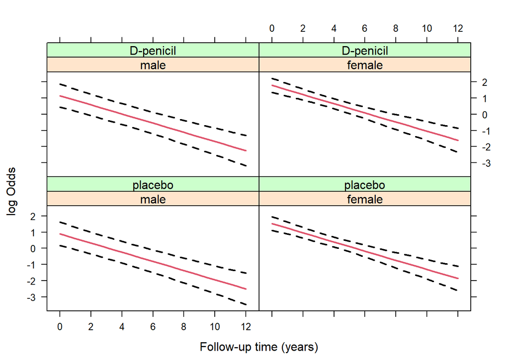

```r
xyplot(pred + low + upp ~ year | sex * drug,
       data = effectPlotData(fm_3, newDF),
       type = "l", lty = c(1, 2, 2), col = c(2, 1, 1), lwd = 2,
       xlab = "Follow-up time (years)",
       ylab = "log Odds")
```

### Question 8

Following we produce the plot of the marginal probabilities of abnormal prothrombin time;

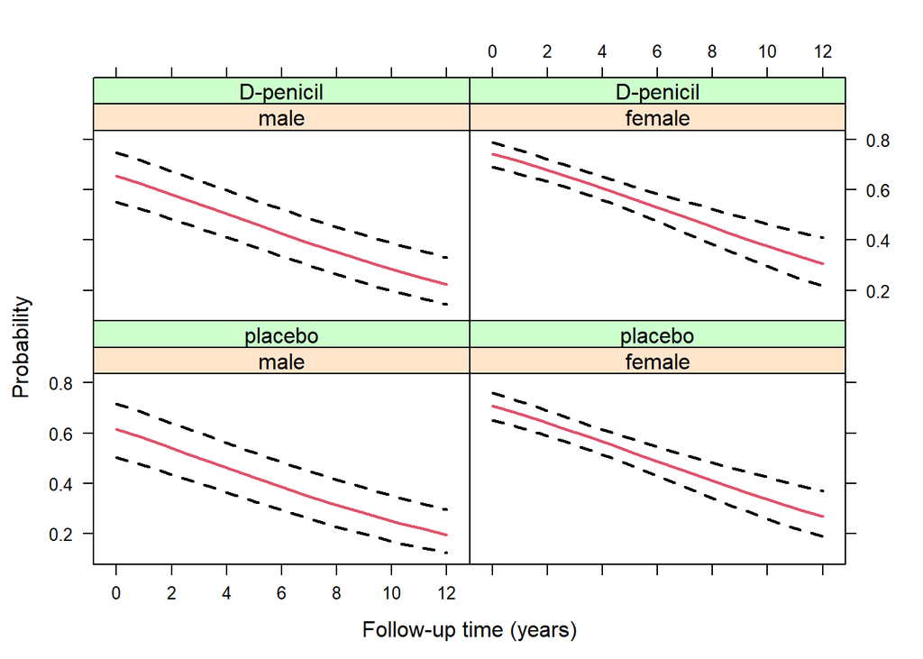

```r
plot_data_marginal <- effectPlotData(fm_3, newDF, marginal = TRUE)

expit <- function (x) exp(x) / (1 + exp(x))
xyplot(expit(pred) + expit(low) + expit(upp) ~ year | sex * drug,
       data = plot_data_marginal,
       type = "l", lty = c(1, 2, 2), col = c(2, 1, 1), lwd = 2,
       xlab = "Follow-up time (years)", ylab = "Probability")
```

To see the difference between the marginal probabilities and the proability corresponding to the average subject, we superimpose the latter in the last figure using the code:

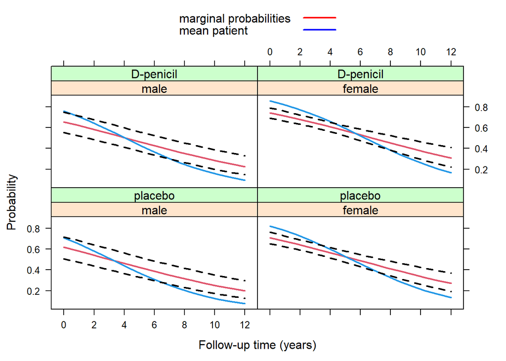

```r
plot_data_marginal$pred0 <- effectPlotData(fm_3, newDF)$pred

expit <- function (x) exp(x) / (1 + exp(x))
key <- simpleKey(c("marginal probabilities", "mean patient"), points = FALSE,
                 lines = TRUE)
key$lines$col <- c("red", "blue")
key$lines$lwd <- c(2, 2)
xyplot(expit(pred) + expit(pred0) + expit(low) + expit(upp) ~ year | sex * drug,
       data = plot_data_marginal, key = key,
       type = "l", lty = c(1, 1, 2, 2), col = c(2, 4, 1, 1), lwd = 2,
       xlab = "Follow-up time (years)", ylab = "Probability")
```